# Операционные системы

Лабораторная работа № 12. Программирование в командном процессоре ОС UNIX. Расширенное программирование.

Акрур Имад.

Российский университет дружбы народов, Москва, Россия

03.05.2025

# Информация

## Докладчик

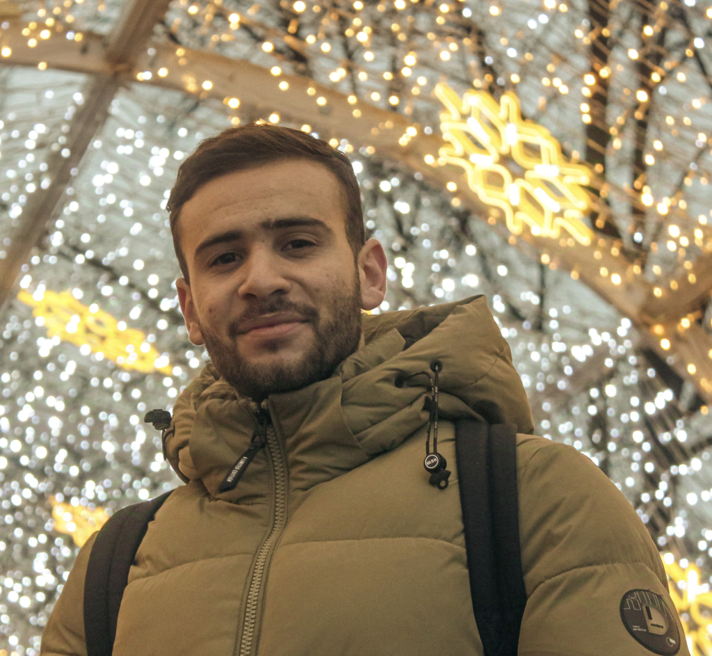

## Цель работы:

- Изучить основы программирования в оболочке ОС UNIX. Научиться писать более сложные командные файлы с использованием логических управляющих конструкций и циклов.

## Материалы и методы

- Терминал Unix.
- Файловая система.
- Текстовой редактор emacs .

## Ход работы:

## Написание первой программы:

- Здесь я написал файл bash, реализующий упрощенный механизм семафора. Командный файл должен некоторое время t1 ждать освобождения ресурса, выдавая сообщение об этом, и после ожидания его освобождения использовать его в течение некоторого времени t2<>t1, также предоставляя информацию о том, что ресурс используется соответствующим командным файлом (процессом)

## Написание первой программы:

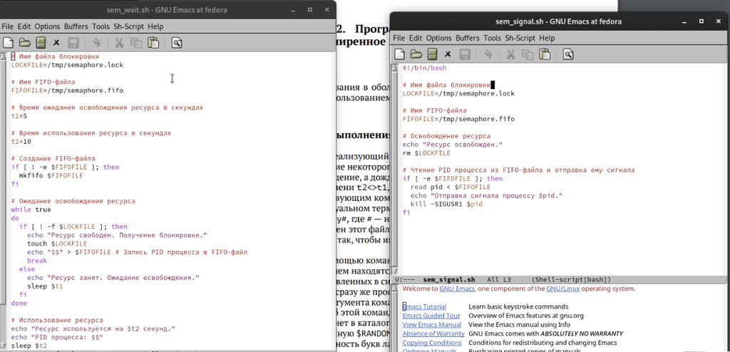

Написание первой программы

## выполнение первой программы

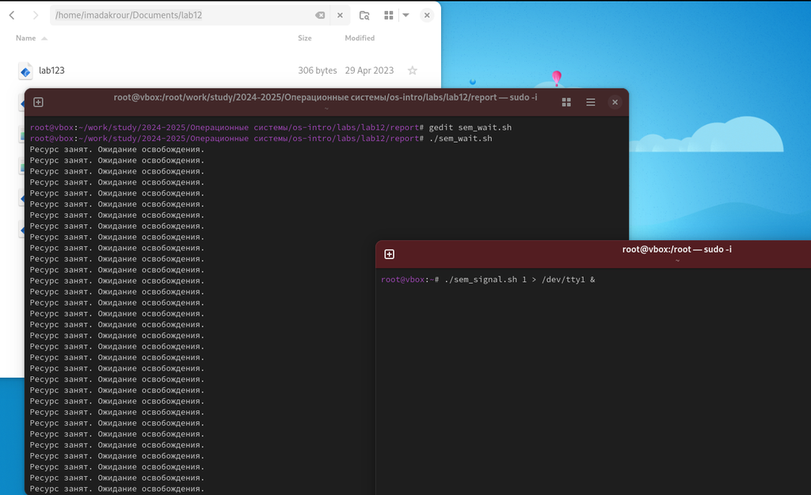

выполнение первой программы

## Написание второй программы

- После этого я написал скрипт bash, который использует содержимое map log /usr/share/man/man1. Он содержит архивы текстовых файлов, содержащих справку по большинству программ и команд, установленных в системе, а затем отображает справку по выбранной команде

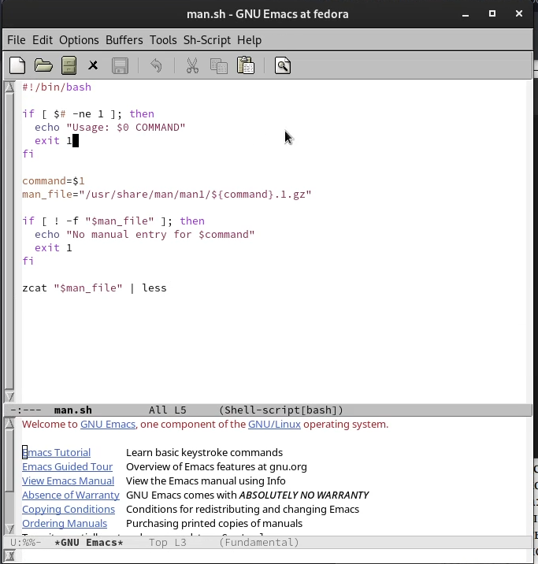

Написание второй программы

## выполнение второй программы

- после этого я выполнил код скрипта, чтобы проверить справку команды cp, и он показал мне справку этой команды

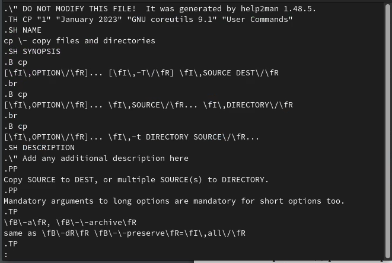

выполнение второй программы

## Написание третьей программы]

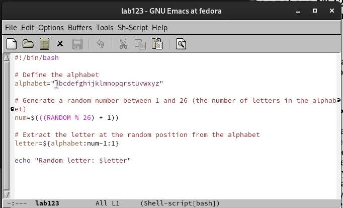

Написание третьей программы

## выполнение третьей программы

- а потом я выполнил программу, и все заработало

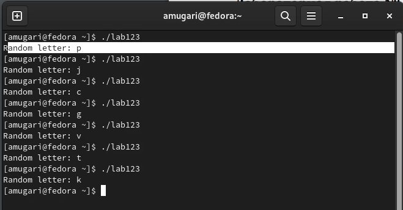

выполнение третьей программы

## выводы по результатам выполнения заданий:

- В ходе этой лабораторной работы у меня была возможность научиться программировать в операционной системе UNIX и приобрести практические навыки написания сложного кода с использованием логических управляющих структур и циклов.

# Выводы, согласованные с целью работы:

- Изучить основы программирования в оболочке ОС UNIX. Научится писать более сложные командные файлы с использованием логических управляющих конструкций и циклов.